# Race analysis of national prison data

Benjamin Nickerson

2/25/2022

The historical nature of policing and prisons in the US is that they have always been tools of oppression. Using the Vera Institutes dataset, I will be investigating links between time, race, incarceration rates and prison populations.

As I interrogated this dataset, I found a couple variables interesting. First, I looked at what information was really in the dataset. I found that the states CT, DE, HI, RI, VT lacked data, and that AK also had very sub par data. I made note of that, understanding the image we got from this dataset was not necessarily perfect. I then needed to ask, what state has the most people in prison (as up to date as 2018)? The answer is CA, but I already knew that I would need to interrogate this number further. California is the most populous state after all, so I needed to ask what state actually has the greatest number of people in prison vs the states population of people in the normal age range for incarceration (i will just refer to this as population). That number would tell us what state incarcerates more people per capita than other states, which happens to be LA, Louisiana. Looking at another piece of general analysis I found that around 13.48% of the US population was black. 33.26% of Louisiana is black, but amazingly, 58.26% of their prisons are black. In fact, 33.58% of the entire US prison population is black, well over double the around 13 percent they make up.

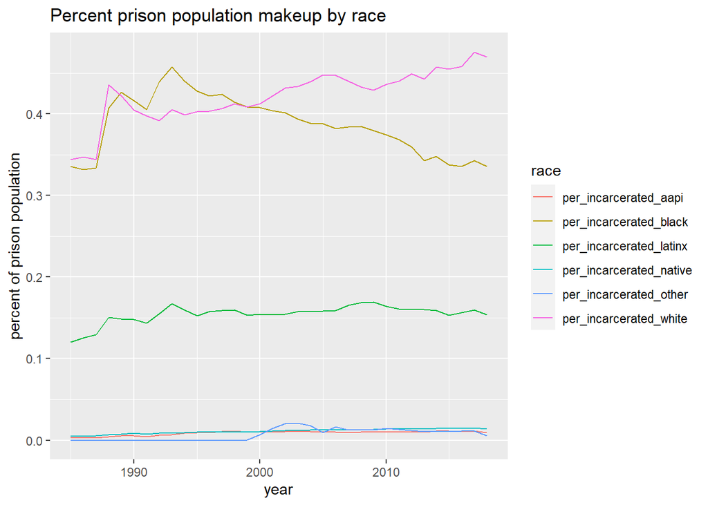

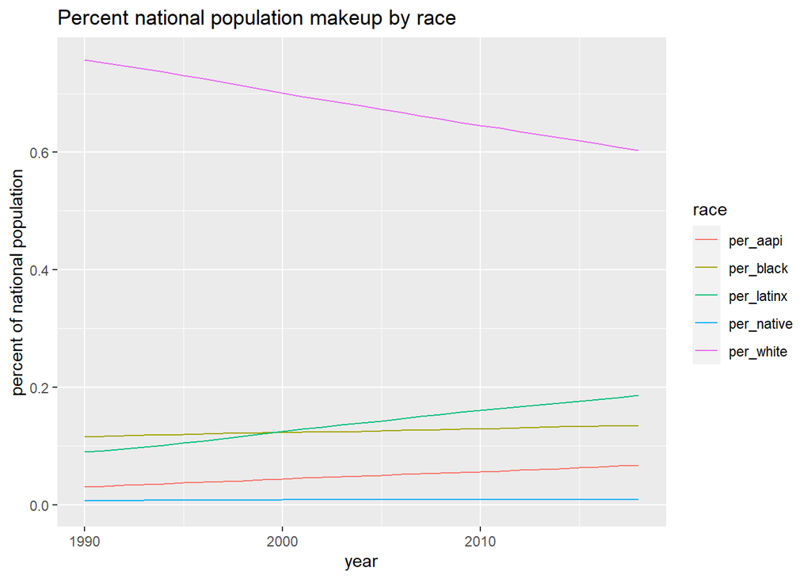

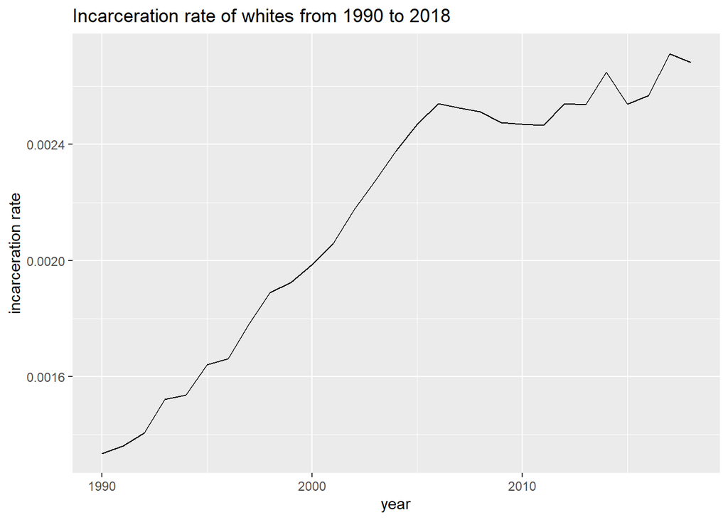

When I was prying through this dataset, I found some interesting trends I thought were worth calling attention to, specifically about how cultural density might provide some security to minorities. I found that the smaller the population of black individuals is in a given county, the higher the incareration rate of black individuals is in that county. It seems that a larger minority population provides some protection from the worst of overpolicing, and that the opposite might be true.

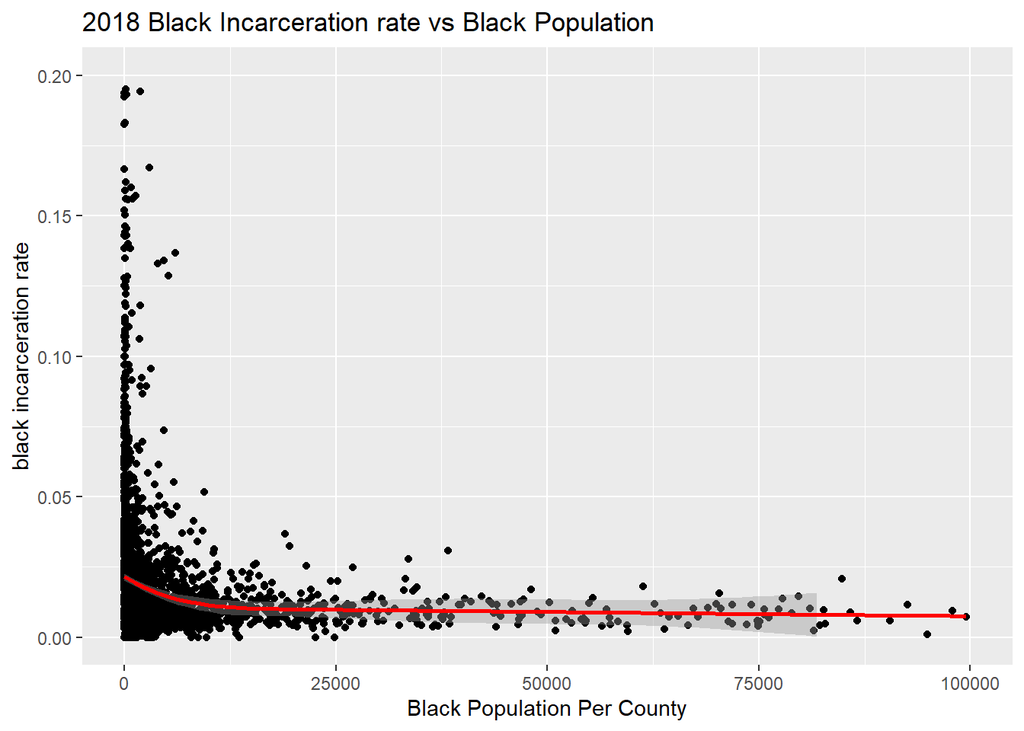

Finally, looking at a map of what places have the highest black incarceration rate we can get an idea of where the problem of overpolicing is most prevelant. I will let readers draw their own conclusions on why the history, and current politics, of these places might lead to more discriminitory incarceration laws.

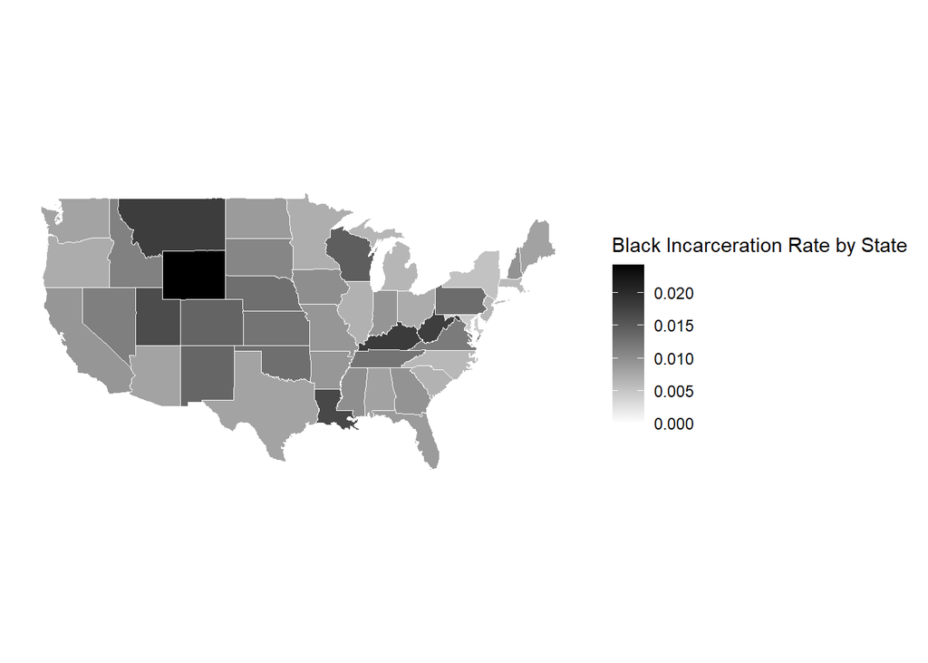